# Sparkify Project Workspace

This workspace contains a tiny subset (128MB) of the full dataset available (12GB). Feel free to use this workspace to build your project, or to explore a smaller subset with Spark before deploying your cluster on the cloud. Instructions for setting up your Spark cluster is included in the last lesson of the Extracurricular Spark Course content.

You can follow the steps below to guide your data analysis and model building portion of this project.

```python
#!pip install seaborn --upgrade
```

```python
# import libraries
import pandas as pd
import numpy as np
import json
import matplotlib.pyplot as plt
import seaborn as sns
import datetime

import pyspark
from pyspark import SparkConf
from pyspark.sql import SparkSession
from pyspark.sql.functions import udf
from pyspark.sql.types import StringType, DateType
from pyspark.sql.types import IntegerType
from pyspark.sql.functions import desc
from pyspark.sql.functions import asc
from pyspark.sql.functions import sum as Fsum,  min as Fmin, max as Fmax
from pyspark.sql import functions as F
from pyspark.sql import Window
from pyspark.sql.functions import from_unixtime
from pyspark.ml.feature import StringIndexer

pd.options.display.max_columns = 0
```

```python
np.__version__
```

```
'1.12.1'
```

```python
# create a Spark session
spark = SparkSession.builder.appName("Sparkify").getOrCreate()
```

```python
# get information
spark
```

**SparkSession - in-memory**

**SparkContext**

[Spark UI](http://e773bc4bcef4:4040)

**Version**

`v2.4.3`

**Master**

`local[*]`

**AppName**

`Sparkify`

# Load and Clean Dataset

In this workspace, the mini-dataset file is `mini_sparkify_event_data.json`. Load and clean the dataset, checking for invalid or missing data - for example, records without userids or sessionids.

```python
# load dataset
df = spark.read.json('mini_sparkify_event_data.json')
```

```python
# load full dataset

#df = spark.read.json('s3n://udacity-dsnd/sparkify/sparkify_event_data.json')
```

```python
# print schema
df.printSchema()
```

```
root
 |-- artist: string (nullable = true)
 |-- auth: string (nullable = true)
 |-- firstName: string (nullable = true)
 |-- gender: string (nullable = true)
 |-- itemInSession: long (nullable = true)
 |-- lastName: string (nullable = true)
 |-- length: double (nullable = true)
 |-- level: string (nullable = true)
 |-- location: string (nullable = true)
 |-- method: string (nullable = true)
 |-- page: string (nullable = true)
 |-- registration: long (nullable = true)
 |-- sessionId: long (nullable = true)
 |-- song: string (nullable = true)
 |-- status: long (nullable = true)
 |-- ts: long (nullable = true)
 |-- userAgent: string (nullable = true)
 |-- userId: string (nullable = true)
```

```python
# check row data
df.head(2)
```

```
[Row(artist='Martha Tilston', auth='Logged In', firstName='Colin', gender='M', itemInSession=50, lastName='Freeman', length=277.89016, level='paid', location='Bakersfield, CA', method='PUT', page='NextSong', registration=1538173362000, sessionId=29, song='Rockpools', status=200, ts=1538352117000, us…
 Row(artist='Five Iron Frenzy', auth='Logged In', firstName='Micah', gender='M', itemInSession=79, lastName='Long', length=236.09424, level='free', location='Boston-Cambridge-Newton, MA-NH', method='PUT', page='NextSong', registration=1538331630000, sessionId=8, song='Canada', status=200, ts=1538352…
```

```python
# convert unixtime to datetime
df = df.withColumn('datetime', from_unixtime(df.ts/1000))
```

```python
# use pandas to check with readable format
df_5 = df.limit(5).toPandas()
df_5.head()
```

|  | artist | auth | firstName | gender | itemInSession | lastName | length | level | location | method | page | registration | sessionId | song | status | ts | userAgent | userId | datetime |
| --- | --- | --- | --- | --- | --- | --- | --- | --- | --- | --- | --- | --- | --- | --- | --- | --- | --- | --- | --- |
| 0 | Martha Tilston | Logged In | Colin | M | 50 | Freeman | 277.89016 | paid | Bakersfield, CA | PUT | NextSong | 1538173362000 | 29 | Rockpools | 200 | 1538352117000 | Mozilla/5.0 (Windows NT 6.1; WOW64; rv:31.0) G... | 30 | 2018-10-01 00:01:57 |
| 1 | Five Iron Frenzy | Logged In | Micah | M | 79 | Long | 236.09424 | free | Boston-Cambridge-Newton, MA-NH | PUT | NextSong | 1538331630000 | 8 | Canada | 200 | 1538352180000 | "Mozilla/5.0 (Windows NT 6.1; WOW64) AppleWebK... | 9 | 2018-10-01 00:03:00 |
| 2 | Adam Lambert | Logged In | Colin | M | 51 | Freeman | 282.82730 | paid | Bakersfield, CA | PUT | NextSong | 1538173362000 | 29 | Time For Miracles | 200 | 1538352394000 | Mozilla/5.0 (Windows NT 6.1; WOW64; rv:31.0) G... | 30 | 2018-10-01 00:06:34 |
| 3 | Enigma | Logged In | Micah | M | 80 | Long | 262.71302 | free | Boston-Cambridge-Newton, MA-NH | PUT | NextSong | 1538331630000 | 8 | Knocking On Forbidden Doors | 200 | 1538352416000 | "Mozilla/5.0 (Windows NT 6.1; WOW64) AppleWebK... | 9 | 2018-10-01 00:06:56 |
| 4 | Daft Punk | Logged In | Colin | M | 52 | Freeman | 223.60771 | paid | Bakersfield, CA | PUT | NextSong | 1538173362000 | 29 | Harder Better Faster Stronger | 200 | 1538352676000 | Mozilla/5.0 (Windows NT 6.1; WOW64; rv:31.0) G... | 30 | 2018-10-01 00:11:16 |

```python
# total data count
df.count()
```

```
286500
```

## Cleanup data

```python
# check null valuse
column_null_count = {col:df.filter(df[col].isNull()).count() for col in df.columns}
column_null_count
```

```
{'artist': 58392,
 'auth': 0,
 'firstName': 8346,
 'gender': 8346,
 'itemInSession': 0,
 'lastName': 8346,
 'length': 58392,
 'level': 0,
 'location': 8346,
 'method': 0,
 'page': 0,
 'registration': 8346,
 'sessionId': 0,
 'song': 58392,
 'status': 0,
 'ts': 0,
 'userAgent': 8346,
 'userId': 0,
 'datetime': 0}
```

```python
# check userid
df.select("userId").dropDuplicates().sort("userId").show()
```

```
+------+
|userId|
+------+
|      |
|    10|
|   100|
|100001|
|100002|
|100003|
|100004|
|100005|
|100006|
|100007|
|100008|
|100009|
|100010|
|100011|
|100012|
|100013|
|100014|
|100015|
|100016|
|100017|
+------+
only showing top 20 rows
```

```python
# remove empty userid rows
print(f'prev: {df.count()}')
df = df.filter(df["userId"]!="")
print(f'after: {df.count()}')
```

```
prev: 286500
after: 278154
```

# Exploratory Data Analysis

When you're working with the full dataset, perform EDA by loading a small subset of the data and doing basic manipulations within Spark. In this workspace, you are already provided a small subset of data you can explore.

### Define Churn

Once you've done some preliminary analysis, create a column `Churn` to use as the label for your model. I suggest using the `Cancellation Confirmation` events to define your churn, which happen for both paid and free users. As a bonus task, you can also look into the `Downgrade` events.

### Explore Data

Once you've defined churn, perform some exploratory data analysis to observe the behavior for users who stayed vs users who churned. You can start by exploring aggregates on these two groups of users, observing how much of a specific action they experienced per a certain time unit or number of songs played.

```python
# count records by page
df.groupby('page').count().orderBy(desc('count')).show(100)
```

```
+--------------------+------+
|                page| count|
+--------------------+------+
|            NextSong|228108|
|           Thumbs Up| 12551|
|                Home| 10082|
|     Add to Playlist|  6526|
|          Add Friend|  4277|
|         Roll Advert|  3933|
|              Logout|  3226|
|         Thumbs Down|  2546|
|           Downgrade|  2055|
|            Settings|  1514|
|                Help|  1454|
|             Upgrade|   499|
|               About|   495|
|       Save Settings|   310|
|               Error|   252|
|      Submit Upgrade|   159|
|    Submit Downgrade|    63|
|              Cancel|    52|
|Cancellation Conf...|    52|
+--------------------+------+
```

```python
# create churn column
cancel_event = udf(lambda x: 1 if x == 'Cancellation Confirmation' else 0, IntegerType())
df = df.withColumn('churn', cancel_event('page'))

#create downgrade column
downgrade_event = udf(lambda x: 1 if x == 'Downgrade' else 0, IntegerType())
df = df.withColumn('downgrade', downgrade_event('page'))
```

```python
# flag churned user
windowval = Window.partitionBy("userId").orderBy(desc("ts")).rangeBetween(Window.unboundedPreceding, 0)
df = df.withColumn("churn", Fsum("churn").over(windowval))
```

```python
# show cancelled user
#df.filter("page == 'Cancellation Confirmation'").head()
# 125 user canceled
df.filter("userId == '125'").select(['userId', 'page', 'churn', 'downgrade', 'datetime']).orderBy('ts').collect()
```

```
[Row(userId='125', page='NextSong', churn=1, downgrade=0, datetime='2018-10-12 04:05:44'),
 Row(userId='125', page='NextSong', churn=1, downgrade=0, datetime='2018-10-12 04:11:21'),
 Row(userId='125', page='NextSong', churn=1, downgrade=0, datetime='2018-10-12 04:15:11'),
 Row(userId='125', page='NextSong', churn=1, downgrade=0, datetime='2018-10-12 04:18:34'),
 Row(userId='125', page='NextSong', churn=1, downgrade=0, datetime='2018-10-12 04:22:04'),
 Row(userId='125', page='NextSong', churn=1, downgrade=0, datetime='2018-10-12 04:28:35'),
 Row(userId='125', page='NextSong', churn=1, downgrade=0, datetime='2018-10-12 04:32:08'),
 Row(userId='125', page='NextSong', churn=1, downgrade=0, datetime='2018-10-12 04:35:06'),
 Row(userId='125', page='Roll Advert', churn=1, downgrade=0, datetime='2018-10-12 04:35:17'),
 Row(userId='125', page='Cancel', churn=1, downgrade=0, datetime='2018-10-12 04:35:18'),
 Row(userId='125', page='Cancellation Confirmation', churn=1, downgrade=0, datetime='2018-10-12 04:35:18')]
```

```python
# check date's date time
df.agg(Fmin(df.datetime), Fmax(df.datetime)).show()
```

```
+-------------------+-------------------+
|      min(datetime)|      max(datetime)|
+-------------------+-------------------+
|2018-10-01 00:01:57|2018-12-03 01:11:16|
+-------------------+-------------------+
```

```python
# create played hour column
get_hour = udf(lambda x: datetime.datetime.fromtimestamp(x / 1000.0). hour)
df = df.withColumn("hour", get_hour(df.ts))
songs_in_hour = df.filter(df.page == "NextSong").groupby(df.hour, df.churn).count().orderBy(df.hour.cast("float"))
songs_in_hour.show()
```

```
+----+-----+-----+
|hour|churn|count|
+----+-----+-----+
|   0|    0| 7527|
|   0|    1| 1535|
|   1|    0| 7035|
|   1|    1| 1353|
|   2|    1| 1322|
|   2|    0| 7014|
|   3|    1| 1292|
|   3|    0| 7063|
|   4|    1| 1233|
|   4|    0| 6914|
|   5|    0| 6960|
|   5|    1| 1218|
|   6|    0| 6836|
|   6|    1| 1218|
|   7|    1| 1218|
|   7|    0| 6873|
|   8|    0| 7023|
|   8|    1| 1230|
|   9|    0| 7268|
|   9|    1| 1230|
+----+-----+-----+
only showing top 20 rows
```

```python
# plot song played count and time
songs_in_hour_pd = songs_in_hour.toPandas()
songs_in_hour_pd.hour = pd.to_numeric(songs_in_hour_pd.hour)

# s = sns.scatterplot(data=songs_in_hour_pd, x="hour", y="count", hue='churn')
# s.set(title="Songs played", xlabel='Hour', ylabel='Song count')
# s.set(xlim=(-1, 24))
# s.set(ylim=(0, 1.2 * max(songs_in_hour_pd["count"])))
```

```
Text(0.5,1,'Song played  in a day ')
```

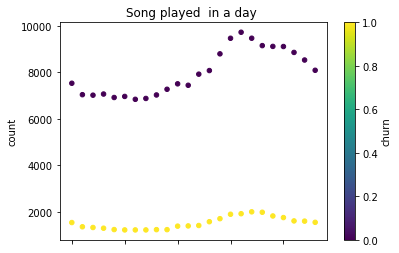

```python
songs_in_hour_pd.plot.scatter(x='hour',
                      y='count',
                      c='churn',
                      colormap='viridis')
plt.ylabel('count')
plt.xlabel('hour')
plt.title('Song played  in a day ')
```

```python
# check churn by gender

churn_by_gender_df = df.groupby(df.gender, df.churn).count().toPandas()
churn_by_gender_df
```

|  | gender | churn | count |
| --- | --- | --- | --- |
| 0 | F | 0 | 135410 |
| 1 | F | 1 | 19168 |
| 2 | M | 0 | 97880 |
| 3 | M | 1 | 25696 |

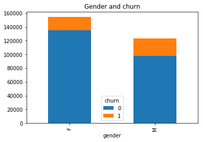

```python
# plot bar chart
churn_by_gender_df.pivot(index='gender', columns='churn', values='count').plot.bar(stacked=True, title='Gender and churn');
```

```python
churned = np.array(churn_by_gender_df[churn_by_gender_df['churn'] == 1]['count'])
user_all = np.array(churn_by_gender_df.groupby('gender').sum()['count'])
p = (churned / user_all )* 100
print(f"Cancel rate F: {p[0]:.2f}%     M: {p[1]:.2f}%" )
```

```
Cancel rate F: 12.40%     M: 20.79%
```

```python
# check churn by level
churn_by_level_df = df.groupby(df.level, df.churn).count().toPandas()
churn_by_level_df
```

|  | level | churn | count |
| --- | --- | --- | --- |
| 0 | free | 0 | 43333 |
| 1 | paid | 0 | 189957 |
| 2 | free | 1 | 12388 |
| 3 | paid | 1 | 32476 |

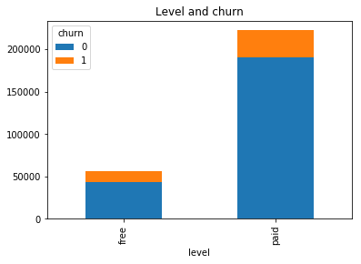

```python
# plot bar chart
churn_by_level_df.pivot(index='level', columns='churn', values='count').plot.bar(stacked=True, title='Level and churn')
```

```python
churned = np.array(churn_by_level_df[churn_by_level_df['churn'] == 1]['count'])
user_all = np.array(churn_by_level_df.groupby('level').sum()['count'])
p = (churned / user_all )* 100
print(f"Cancel rate Free: {p[0]:.2f}%     Paied: {p[1]:.2f}%" )
```

```
Cancel rate Free: 22.23%     Paied: 14.60%
```

```python
df.limit(10).select('location').show()
```

```
+--------------------+
|            location|
+--------------------+
|     Bakersfield, CA|
|Boston-Cambridge-...|
|     Bakersfield, CA|
|Boston-Cambridge-...|
|     Bakersfield, CA|
|Boston-Cambridge-...|
|Boston-Cambridge-...|
|     Bakersfield, CA|
|     Bakersfield, CA|
|     Bakersfield, CA|
+--------------------+
```

```python
# find by location
# find by location

def find_location(location_str):
    try:
        locations = location_str.split(',')
        if 0 < len(locations):
            return locations[1].strip()
    except:
        pass

    return ''

#get_location_chr = udf(lambda x: (x.split(',')[1]).strip())
get_location_chr = udf(lambda x: find_location(x))

df = df.withColumn("location_code", get_location_chr(df.location))

location_df = df.groupby('location_code', 'churn').count().orderBy(desc('count')).toPandas()
```

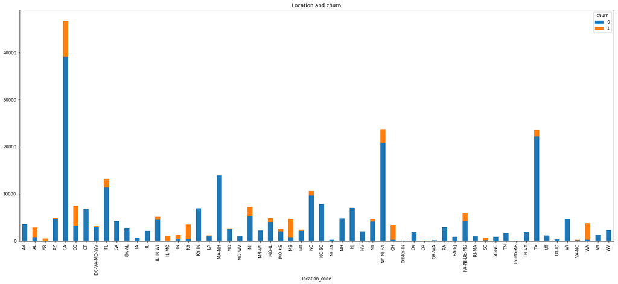

```python
#plot chart
location_df.pivot(index='location_code', columns='churn', values='count').plot.bar(stacked=True, title='Location and churn', figsize=(25,10))
```

```python
# check user agents
list(df.groupby('userAgent').count().orderBy(desc('count')).select('userAgent').toPandas()['userAgent'])
```

```
['"Mozilla/5.0 (Windows NT 6.1; WOW64) AppleWebKit/537.36 (KHTML, like Gecko) Chrome/36.0.1985.143 Safari/537.36"',
 '"Mozilla/5.0 (Macintosh; Intel Mac OS X 10_9_4) AppleWebKit/537.77.4 (KHTML, like Gecko) Version/7.0.5 Safari/537.77.4"',
 '"Mozilla/5.0 (Macintosh; Intel Mac OS X 10_9_4) AppleWebKit/537.36 (KHTML, like Gecko) Chrome/36.0.1985.125 Safari/537.36"',
 '"Mozilla/5.0 (Macintosh; Intel Mac OS X 10_9_4) AppleWebKit/537.36 (KHTML, like Gecko) Chrome/36.0.1985.143 Safari/537.36"',
 'Mozilla/5.0 (Windows NT 6.1; WOW64; rv:31.0) Gecko/20100101 Firefox/31.0',
 '"Mozilla/5.0 (Windows NT 6.1; WOW64) AppleWebKit/537.36 (KHTML, like Gecko) Chrome/36.0.1985.125 Safari/537.36"',
 '"Mozilla/5.0 (Windows NT 6.1; WOW64) AppleWebKit/537.36 (KHTML, like Gecko) Chrome/37.0.2062.103 Safari/537.36"',
 'Mozilla/5.0 (Macintosh; Intel Mac OS X 10.9; rv:31.0) Gecko/20100101 Firefox/31.0',
 '"Mozilla/5.0 (iPad; CPU OS 7_1_2 like Mac OS X) AppleWebKit/537.51.2 (KHTML, like Gecko) Version/7.0 Mobile/11D257 Safari/9537.53"',
 'Mozilla/5.0 (compatible; MSIE 9.0; Windows NT 6.1; WOW64; Trident/5.0)',
 '"Mozilla/5.0 (Macintosh; Intel Mac OS X 10_9_4) AppleWebKit/537.78.2 (KHTML, like Gecko) Version/7.0.6 Safari/537.78.2"',
 '"Mozilla/5.0 (Windows NT 6.1) AppleWebKit/537.36 (KHTML, like Gecko) Chrome/36.0.1985.143 Safari/537.36"',
 '"Mozilla/5.0 (Macintosh; Intel Mac OS X 10_9_4) AppleWebKit/537.36 (KHTML, like Gecko) Chrome/37.0.2062.94 Safari/537.36"',
 '"Mozilla/5.0 (Windows NT 6.3; WOW64) AppleWebKit/537.36 (KHTML, like Gecko) Chrome/36.0.1985.143 Safari/537.36"',
 '"Mozilla/5.0 (iPhone; CPU iPhone OS 7_1_2 like Mac OS X) AppleWebKit/537.51.2 (KHTML, like Gecko) Version/7.0 Mobile/11D257 Safari/9537.53"',
 'Mozilla/5.0 (Windows NT 6.3; WOW64; rv:31.0) Gecko/20100101 Firefox/31.0',
 '"Mozilla/5.0 (Macintosh; Intel Mac OS X 10_10) AppleWebKit/600.1.8 (KHTML, like Gecko) Version/8.0 Safari/600.1.8"',
 '"Mozilla/5.0 (Windows NT 5.1) AppleWebKit/537.36 (KHTML, like Gecko) Chrome/36.0.1985.143 Safari/537.36"',
 '"Mozilla/5.0 (Windows NT 6.3; WOW64) AppleWebKit/537.36 (KHTML, like Gecko) Chrome/36.0.1985.125 Safari/537.36"',
 'Mozilla/5.0 (Windows NT 6.1; WOW64; Trident/7.0; rv:11.0) like Gecko',
 '"Mozilla/5.0 (Windows NT 6.1; WOW64) AppleWebKit/537.36 (KHTML, like Gecko) Chrome/37.0.2062.94 Safari/537.36"',
 'Mozilla/5.0 (Windows NT 6.1; WOW64; rv:32.0) Gecko/20100101 Firefox/32.0',
 'Mozilla/5.0 (Windows NT 6.1; WOW64; rv:30.0) Gecko/20100101 Firefox/30.0',
 '"Mozilla/5.0 (Windows NT 6.2; WOW64) AppleWebKit/537.36 (KHTML, like Gecko) Chrome/36.0.1985.125 Safari/537.36"',
 '"Mozilla/5.0 (X11; Linux x86_64) AppleWebKit/537.36 (KHTML, like Gecko) Chrome/36.0.1985.143 Safari/537.36"',
 '"Mozilla/5.0 (Macintosh; Intel Mac OS X 10_9_2) AppleWebKit/537.36 (KHTML, like Gecko) Chrome/36.0.1985.125 Safari/537.36"',
 '"Mozilla/5.0 (iPhone; CPU iPhone OS 7_1 like Mac OS X) AppleWebKit/537.51.2 (KHTML, like Gecko) Version/7.0 Mobile/11D167 Safari/9537.53"',
 'Mozilla/5.0 (X11; Linux x86_64; rv:31.0) Gecko/20100101 Firefox/31.0',
 '"Mozilla/5.0 (iPad; CPU OS 7_1_1 like Mac OS X) AppleWebKit/537.51.2 (KHTML, like Gecko) Version/7.0 Mobile/11D201 Safari/9537.53"',
 'Mozilla/5.0 (Macintosh; Intel Mac OS X 10.7; rv:31.0) Gecko/20100101 Firefox/31.0',
 'Mozilla/5.0 (Windows NT 6.0; rv:31.0) Gecko/20100101 Firefox/31.0',
 '"Mozilla/5.0 (Windows NT 6.1; WOW64) AppleWebKit/537.36 (KHTML, like Gecko) Chrome/35.0.1916.153 Safari/537.36"',
 '"Mozilla/5.0 (Windows NT 5.1) AppleWebKit/537.36 (KHTML, like Gecko) Chrome/36.0.1985.125 Safari/537.36"',
 'Mozilla/5.0 (Windows NT 6.2; WOW64; rv:31.0) Gecko/20100101 Firefox/31.0',
 '"Mozilla/5.0 (Windows NT 6.1) AppleWebKit/537.36 (KHTML, like Gecko) Chrome/36.0.1985.125 Safari/537.36"',
 '"Mozilla/5.0 (Macintosh; Intel Mac OS X 10_9_3) AppleWebKit/537.76.4 (KHTML, like Gecko) Version/7.0.4 Safari/537.76.4"',
 '"Mozilla/5.0 (iPhone; CPU iPhone OS 7_1_1 like Mac OS X) AppleWebKit/537.51.2 (KHTML, like Gecko) Version/7.0 Mobile/11D201 Safari/9537.53"',
 'Mozilla/5.0 (Macintosh; Intel Mac OS X 10.8; rv:31.0) Gecko/20100101 Firefox/31.0',
 'Mozilla/5.0 (X11; Ubuntu; Linux x86_64; rv:31.0) Gecko/20100101 Firefox/31.0',
 '"Mozilla/5.0 (X11; Linux x86_64) AppleWebKit/537.36 (KHTML, like Gecko) Chrome/36.0.1985.125 Safari/537.36"',
 '"Mozilla/5.0 (Macintosh; Intel Mac OS X 10_10) AppleWebKit/600.1.3 (KHTML, like Gecko) Version/8.0 Safari/600.1.3"',
 '"Mozilla/5.0 (Macintosh; Intel Mac OS X 10_9_4) AppleWebKit/537.36 (KHTML, like Gecko) Chrome/35.0.1916.153 Safari/537.36"',
 'Mozilla/5.0 (compatible; MSIE 9.0; Windows NT 6.1; Trident/5.0)',
 'Mozilla/5.0 (Windows NT 6.1; WOW64; rv:24.0) Gecko/20100101 Firefox/24.0',
 '"Mozilla/5.0 (Macintosh; Intel Mac OS X 10_9_2) AppleWebKit/537.74.9 (KHTML, like Gecko) Version/7.0.2 Safari/537.74.9"',
 'Mozilla/5.0 (Windows NT 6.1; rv:31.0) Gecko/20100101 Firefox/31.0',
 'Mozilla/5.0 (compatible; MSIE 10.0; Windows NT 6.1; WOW64; Trident/6.0)',
 '"Mozilla/5.0 (Macintosh; Intel Mac OS X 10_7_5) AppleWebKit/537.77.4 (KHTML, like Gecko) Version/6.1.5 Safari/537.77.4"',
 '"Mozilla/5.0 (Macintosh; Intel Mac OS X 10_9_2) AppleWebKit/537.75.14 (KHTML, like Gecko) Version/7.0.3 Safari/537.75.14"',
 '"Mozilla/5.0 (Windows NT 6.2; WOW64) AppleWebKit/537.36 (KHTML, like Gecko) Chrome/36.0.1985.143 Safari/537.36"',
 '"Mozilla/5.0 (Macintosh; Intel Mac OS X 10_7_5) AppleWebKit/537.36 (KHTML, like Gecko) Chrome/36.0.1985.125 Safari/537.36"',
 'Mozilla/5.0 (Macintosh; Intel Mac OS X 10.6; rv:31.0) Gecko/20100101 Firefox/31.0',
 '"Mozilla/5.0 (Macintosh; Intel Mac OS X 10_8_5) AppleWebKit/537.36 (KHTML, like Gecko) Chrome/36.0.1985.143 Safari/537.36"',
 '"Mozilla/5.0 (Macintosh; Intel Mac OS X 10_8_5) AppleWebKit/537.36 (KHTML, like Gecko) Chrome/37.0.2062.94 Safari/537.36"',
 '"Mozilla/5.0 (Macintosh; Intel Mac OS X 10_6_8) AppleWebKit/537.36 (KHTML, like Gecko) Chrome/36.0.1985.143 Safari/537.36"',
 'Mozilla/5.0 (X11; Ubuntu; Linux i686; rv:31.0) Gecko/20100101 Firefox/31.0']
```

```python
#create user_gent_category
user_agent_bukets = ['macintosh', 'windows', 'linux', 'iphone', 'ipad']

def  get_useragent(user_agent_str):
    try:
        for agent in user_agent_bukets:
            if agent in user_agent_str.lower():
                return agent
    except:
        pass

    return 'etc'

get_agetn_bucket= udf(lambda x: get_useragent(x), StringType())
df = df.withColumn("useragent_code", get_agetn_bucket('userAgent'))
```

```python
# useragent churn data
useragent_df = df.groupby('useragent_code', 'churn').count().orderBy(desc('count')).toPandas()
```

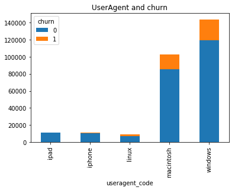

```python
#plot chart
useragent_df.pivot(index='useragent_code', columns='churn', values='count').plot.bar(stacked=True, title='UserAgent and churn')
```

```python
# page and chuan
churn_by_page_df = df.groupby('page', 'churn').count().orderBy(desc('count')).toPandas()
churn_by_page_df
#page_df.pivot(index='page', columns='churn', values='count').plot.bar(stacked=True, title='Page and churn')
```

|  | page | churn | count |
| --- | --- | --- | --- |
| 0 | NextSong | 0 | 191714 |
| 1 | NextSong | 1 | 36394 |
| 2 | Thumbs Up | 0 | 10692 |
| 3 | Home | 0 | 8410 |
| 4 | Add to Playlist | 0 | 5488 |
| 5 | Add Friend | 0 | 3641 |
| 6 | Roll Advert | 0 | 2966 |
| 7 | Logout | 0 | 2673 |
| 8 | Thumbs Down | 0 | 2050 |
| 9 | Thumbs Up | 1 | 1859 |
| 10 | Downgrade | 0 | 1718 |
| 11 | Home | 1 | 1672 |
| 12 | Settings | 0 | 1244 |
| 13 | Help | 0 | 1215 |
| 14 | Add to Playlist | 1 | 1038 |
| 15 | Roll Advert | 1 | 967 |
| 16 | Add Friend | 1 | 636 |
| 17 | Logout | 1 | 553 |
| 18 | Thumbs Down | 1 | 496 |
| 19 | About | 0 | 439 |
| 20 | Upgrade | 0 | 387 |
| 21 | Downgrade | 1 | 337 |
| 22 | Settings | 1 | 270 |
| 23 | Save Settings | 0 | 252 |
| 24 | Help | 1 | 239 |
| 25 | Error | 0 | 220 |
| 26 | Submit Upgrade | 0 | 127 |
| 27 | Upgrade | 1 | 112 |
| 28 | Save Settings | 1 | 58 |
| 29 | About | 1 | 56 |
| 30 | Submit Downgrade | 0 | 54 |
| 31 | Cancellation Confirmation | 1 | 52 |
| 32 | Cancel | 1 | 52 |
| 33 | Error | 1 | 32 |
| 34 | Submit Upgrade | 1 | 32 |
| 35 | Submit Downgrade | 1 | 9 |

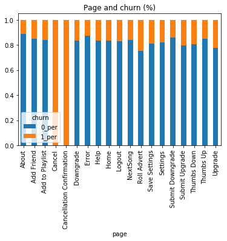

```python
_tmpdf = churn_by_page_df.pivot(index='page', columns='churn', values='count').fillna(0)
_tmpdf['total'] = _tmpdf[0] + _tmpdf[1]
_tmpdf['0_per'] = _tmpdf[0] / _tmpdf['total']
_tmpdf['1_per'] = _tmpdf[1] / _tmpdf['total']
_tmpdf.plot.bar(stacked=True, title='Page and churn (%)', y=['0_per', '1_per'])
```

# Feature Engineering

Once you've familiarized yourself with the data, build out the features you find promising to train your model on. To work with the full dataset, you can follow the following steps.

- Write a script to extract the necessary features from the smaller subset of data
- Ensure that your script is scalable, using the best practices discussed in Lesson 3
- Try your script on the full data set, debugging your script if necessary

If you are working in the classroom workspace, you can just extract features based on the small subset of data contained here. Be sure to transfer over this work to the larger dataset when you work on your Spark cluster.

Going to use these values as a future

- gender
- level
- device
- total song played
- first_ts
- last_ts
- days from start
- free days
- payed days
- total add friend
- total add to playlist
- total downgrade
- total error
- total help
- total home
- total roll advert
- total upgrade
- total thumb down
- total thumb up
- total session
- average time between per session
- average song played per session
- location
- device

```python
# create user_feature_matrix functions


def creae_churn(df=df):
    _df = df.select(['userId', 'churn']).groupby('UserId').agg(F.max('churn').alias('churn'))
    return _df

def create_downgrade(df=df):
    _df = df.select(['userId', 'downgrade']).groupby('userId').agg(F.max('downgrade').alias('downgrade'))
    return _df



# create page count
def create_page_count(page, df=df):
    """
    Create page count by user DataFrame
    :param page: page name string
    :param df: SparkDF
    :return SparkDF
    """
    _df = df.filter(f"page=='{page}'").select(['userId', 'page']).groupby('userId').agg(F.count('page').alias(f'{page}_count'))
    return _df

# gender
def create_gender(df=df):
    """
    Create userId-gender DataFrame
    :param df: SparkDF
    :return id-gender SparkDF
    """
    _df =  df.select(['userId','gender']).groupby('userId').agg(F.last('gender').alias('gender'))
    return _df

# level
def create_level(df=df):
    """
    Create userId-level DataFrame
    :param df: SparkDF
    :return id-level SparkDF
    """
    _df = df.select(['userId','level']).groupby('userId').agg(F.last('level').alias('level'))
    return _df

# song played
def create_song_played(df=df):
    """
    Create song played count by user DataFrame
    :param df: SparkDF
    :return SparkDF
    """
    return create_page_count('NextSong', df)

# first_ts
def create_first_ts(df=df):
    """
    Create First time by user DataFrame
    :param df: SparkDF
    :return SparkDF
    """
    _df = df.select(['userId', 'ts']).groupby('userId').agg(F.min('ts').alias('first_ts'))
    return _df

# last_ts
def create_last_ts(df=df):
    """
    Create Last time by user DataFrame
    :param df: SparkDF
    :return SparkDF
    """
    _df = df.select(['userId', 'ts']).groupby('userId').agg(F.max('ts').alias('last_ts'))
    return _df

# using days (days from start)
def create_days_from_first_to_last(df=df):
    """
    Create days between first use and last use by user DataFrame
    :param df: SparkDF
    :return SparkDF
    """
    _df = df.select(['userId', 'ts']).groupby('userId').agg(((F.max('ts') - F.min('ts'))/(1000*60*60*24)).alias('user_days'))
    return _df

# free days
def create_free_days(df=df):
    """
    Create free level days by user DataFrame
    :param df: SparkDF
    :return SparkDF
    """
    _df = df.select(['userId', 'ts', 'level']).filter("level == 'free'").groupby('userId').agg(((F.max('ts') - F.min('ts'))/(1000*60*60*24)).alias('freeuser_days'))
    return _df

# payed days
def create_paid_days(df=df):
    """
    Create payed level daysby user DataFrame
    :param df: SparkDF
    :return SparkDF
    """
    _df = df.select(['userId', 'ts', 'level']).filter("level == 'paid'").groupby('userId').agg(((F.max('ts') - F.min('ts'))/(1000*60*60*24)).alias('paiduser_days'))
    return _df

# total session
def create_session(df=df):
    """
    Create session average by user DataFrame
    :param df: SparkDF
    :return SparkDF
    """
    _df = df.select(['userId', 'sessionId', 'page']).groupby('userId', 'sessionId').agg(F.count('page').alias('session_count'))\
        .groupby('userId').agg(F.avg('session_count').alias('session_avg'))
    return _df

# - average time between per session
def create_average_time_between_session(df=df):
    """
    Create average time between session sesond by user DataFrame
    :param df: SparkDF
    :return SparkDF
    """
    _df = df.select(['userId', 'sessionId', 'ts']).groupby('userId', 'sessionId').agg(((F.max('ts') - F.min('ts'))/(1000)).alias('session_ts'))\
       .groupby('userId').agg(F.avg('session_ts').alias('session_ts_avg'))
    return _df

# - average song played per session
def create_avg_songplayed_between_session(df=df):
    """
    Create average song count between session
    :param df: SparkDF
    :return SparkDF
    """
    _df = df.select(['userId', 'sessionId', 'page']).filter("page == 'NextSong'").groupby('userId', 'sessionId').agg(F.count('page').alias('song_count'))\
        .groupby('userId').agg(F.avg('song_count').alias('song_avg_per_session'))
    return _df

# location
def create_top_location(df=df):
    """
    Create most common location code by user
    :param df: SparkDF
    :return SparkDF
    """
#    indexer = StringIndexer(inputCol='location_code', outputCol='location_code_cat')

    _df = df.withColumn("location_code", get_location_chr('location'))
    _df = df.select(['userId', 'location_code']).groupby('userId', 'location_code').agg(F.count('location_code').alias('location_code_count'))\
        .orderBy(desc('location_code_count')).groupby('userId').agg(F.first('location_code').alias('location_code'))

    return _df

# device
def create_top_device(df=df):
    """
    Create most common device code by user
    :param df: SparkDF
    :return SparkDF
    """
#     indexer = StringIndexer(inputCol='useragent_code', outputCol='useragent_code_cat')

    _df = df.withColumn("useragent_code", get_agetn_bucket('userAgent'))
    _df = _df.select(['userId', 'useragent_code']).groupby('userId', 'useragent_code').agg(F.count('useragent_code').alias('useragent_code_count'))\
        .orderBy(desc('useragent_code_count')).groupby('userId').agg(F.first('useragent_code').alias('useragent_code'))
    return _df


## test
#create_gender().show()
#create_level().show()
#create_song_played().show()
#create_first_ts().show()
#create_days_from_first_to_last().show()
#create_free_days().show()
#create_paid_days().show()
#create_session().show()
#create_average_time_between_session().show()
#create_avg_songplayed_between_session().show()
#create_top_location().show()
#create_top_device().show()

#creae_churn().show()
#create_downgrade().show()
```

```python
# run separately for debug
```

```python
_gender_df =  create_gender()
```

```python
_level_df = create_level()
```

```python
_song_df = create_song_played()
```

```python
_firstts_df = create_first_ts()
```

```python
_lastts_df = create_last_ts()
```

```python
_fl_days_df = create_days_from_first_to_last()
```

```python
_freedays_df = create_free_days()
```

```python
_paiddays_df = create_paid_days()
```

```python
_session_df = create_session()
```

```python
_avgtime_df = create_average_time_between_session()
```

```python
_avgsong_df = create_avg_songplayed_between_session()
```

```python
_toplocation_df = create_top_location()
```

```python
_topdevice_df = create_top_device()
```

```python
# create combined user-feature matrix
user_feature_df = _gender_df\
    .join(_level_df, on='userId', how='left')\
    .join(_song_df, on='userId', how='left')\
    .join(_firstts_df , on='userId', how='left')\
    .join(_lastts_df, on='userId', how='left')\
    .join(_fl_days_df, on='userId', how='left')\
    .join(_freedays_df, on='userId', how='left')\
    .join(_paiddays_df, on='userId', how='left')\
    .join(_session_df, on='userId', how='left')\
    .join(_avgtime_df, on='userId', how='left')\
    .join(_avgsong_df, on='userId', how='left')\
    .join(creae_churn(), on='userId', how='left')\
    .join(create_downgrade(), on='userId', how='left')\
    .join(create_page_count('Thumbs Up'), on='userId', how='left')\
    .join(create_page_count('Home'), on='userId', how='left')\
    .join(create_page_count('Add to Playlist'), on='userId', how='left')\
    .join(create_page_count('Add Friend'), on='userId', how='left')\
    .join(create_page_count('Roll Advert'), on='userId', how='left')\
    .join(create_page_count('Thumbs Down'), on='userId', how='left')\
    .join(create_page_count('Downgrade'), on='userId', how='left')\
    .join(create_page_count('Help'), on='userId', how='left')\
    .join(create_page_count('Upgrade'), on='userId', how='left')\
    .join(_toplocation_df, on='userId', how='left')\
    .join(_topdevice_df, on='userId', how='left')

user_feature_df = user_feature_df.fillna(0)

user_feature_df.show()
```

```
+------+------+-----+--------------+-------------+-------------+-------------------+-------------------+------------------+------------------+------------------+--------------------+-----+---------+---------------+----------+---------------------+----------------+------------------+-----------------…
|userId|gender|level|NextSong_count|     first_ts|      last_ts|          user_days|      freeuser_days|     paiduser_days|       session_avg|    session_ts_avg|song_avg_per_session|churn|downgrade|Thumbs Up_count|Home_count|Add to Playlist_count|Add Friend_count| Roll Advert_count|Thumbs Down_count…
+------+------+-----+--------------+-------------+-------------+-------------------+-------------------+------------------+------------------+------------------+--------------------+-----+---------+---------------+----------+---------------------+----------------+------------------+-----------------…
|100010|     F| free|           275|1539003534000|1542823952000|  44.21780092592593|  44.21780092592593|               0.0| 54.42857142857143|            9269.0|  39.285714285714285|    0|        0|             17|        11|                    7|               4|                 0|                5…
|200002|     M| paid|           387|1538393430000|1542324354000| 45.496805555555554|  16.91633101851852|28.578645833333333|              79.0|           15984.0|                64.5|    0|        1|             21|        20|                    8|               4|                 0|                6…
|   125|     M| free|             8|1539317144000|1539318918000|0.02053240740740741|0.02053240740740741|               0.0|              11.0|            1774.0|                 8.0|    1|        0|              0|         0|                    0|               0|                 0|                0…
|   124|     F| paid|          4079|1538407030000|1543590766000| 59.996944444444445|                0.0|59.996944444444445| 166.3793103448276| 34739.65517241379|  145.67857142857142|    0|        1|            171|       176|                  118|              74|                 0|               41…
|    51|     M| paid|          2111|1538398632000|1539761972000| 15.779398148148148|                0.0|15.779398148148148|             246.4|           52341.4|               211.1|    1|        1|            100|        75|                   52|              28|                 0|               21…
|     7|     M| free|           150|1538567869000|1542955611000| 50.784050925925925| 50.784050925925925|               0.0|28.714285714285715| 5258.428571428572|  21.428571428571427|    0|        0|              7|        10|                    5|               1|                 0|                1…
|    15|     M| paid|          1914|1538389415000|1543121818000|  54.77318287037037|                0.0| 54.77318287037037|151.86666666666667|           31697.0|  136.71428571428572|    0|        1|             81|        93|                   59|              31|                 0|               14…
|    54|     F| paid|          2841|1538353930000|1542051608000|  42.79719907407407| 13.981747685185185| 42.79719907407407| 92.89189189189189| 19337.37837837838|   81.17142857142858|    1|        1|            163|       129|                   72|              33|                 0|               29…
|   155|     F| paid|           820|1541174185000|1543405710000|  25.82783564814815|  6.418067129629629|19.409131944444443|             167.0|32914.333333333336|  136.66666666666666|    0|        1|             58|        30|                   24|              11|                 0|                3…
|100014|     M| paid|           257|1539177136000|1542740649000| 41.244363425925926|                0.0|41.244363425925926|51.666666666666664|11088.833333333334|  42.833333333333336|    1|        1|             17|         7|                    7|               6|                 0|                3…
|   132|     F| paid|          1928|1538470796000|1542833772000|  50.49740740740741|0.08068287037037038| 50.41633101851852|             144.0|        29937.0625|               120.5|    0|        1|             96|        83|                   38|              41|                 0|               17…
|   154|     F| free|            84|1541171735000|1543330565000| 24.986458333333335| 24.986458333333335|               0.0|39.333333333333336|            6641.0|                28.0|    0|        0|             11|         6|                    1|               3|                 0|                0…
|   101|     M| paid|          1797|1538358605000|1539729037000| 15.861481481481482|  1.666273148148148|14.193136574074074|             214.9|           49054.8|               179.7|    1|        1|             86|        74|                   61|              29|                 0|               16…
```

[output cut: 9 more lines]

```python
# display corr heatmap
user_feature_pandas_df = user_feature_df.toPandas()
corr = user_feature_pandas_df.corr()
```

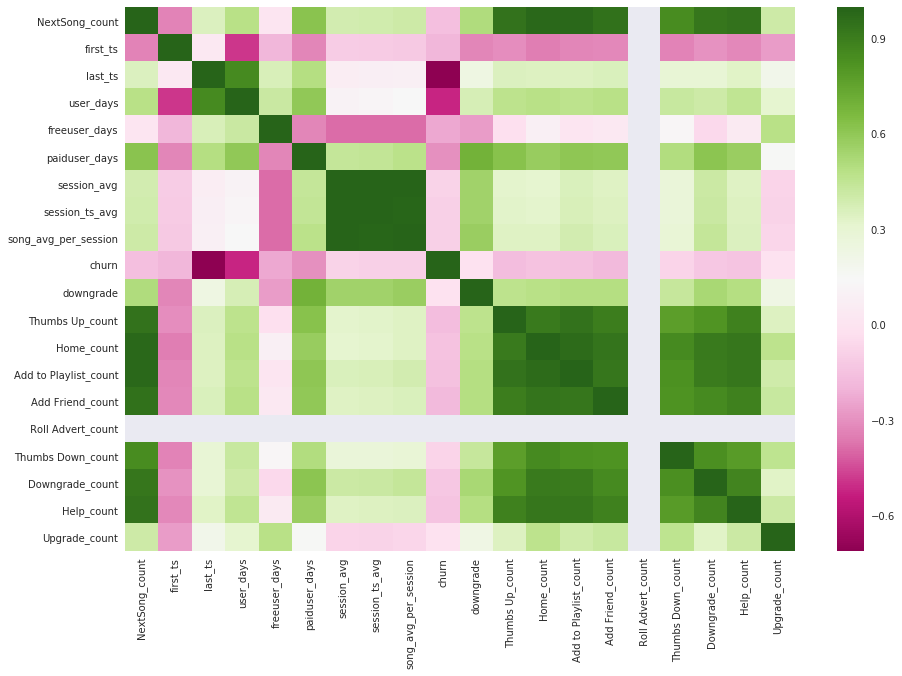

```python
sns.set(rc = {'figure.figsize':(15, 10)})
sns.heatmap(corr, xticklabels=corr.columns, yticklabels=corr.columns, cmap="PiYG")
```

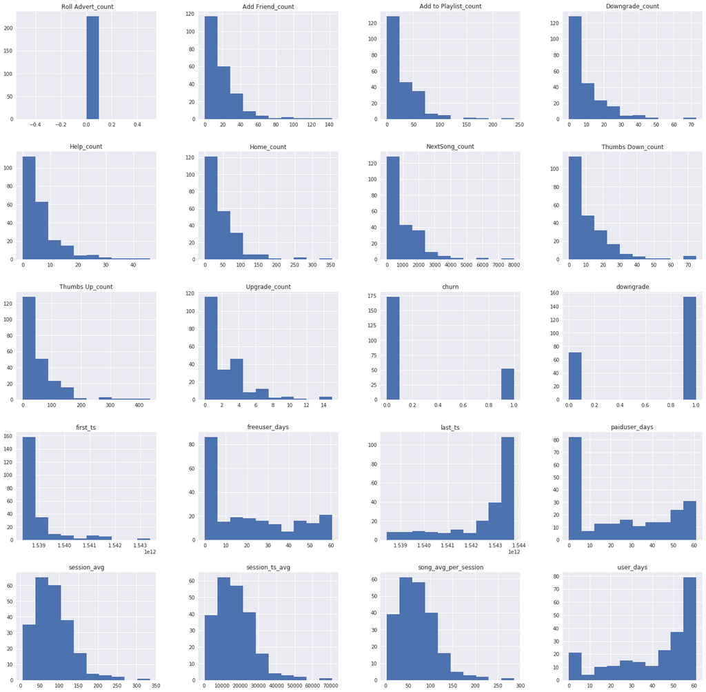

```python
fig = plt.figure(figsize=(25,25))
ax = fig.gca()
h = user_feature_pandas_df.hist(ax=ax)
```

# Modeling

Split the full dataset into train, test, and validation sets. Test out several of the machine learning methods you learned. Evaluate the accuracy of the various models, tuning parameters as necessary. Determine your winning model based on test accuracy and report results on the validation set. Since the churned users are a fairly small subset, I suggest using F1 score as the metric to optimize.

```python
from pyspark.ml.evaluation import MulticlassClassificationEvaluator
from pyspark.ml.feature import CountVectorizer, IDF, Normalizer, PCA, RegexTokenizer, StandardScaler, StopWordsRemover, StringIndexer, VectorAssembler
from pyspark.ml.regression import LinearRegression
from pyspark.ml.classification import LogisticRegression, RandomForestClassifier, GBTClassifier
from pyspark.ml.tuning import CrossValidator, ParamGridBuilder
from pyspark.ml.feature import OneHotEncoder
from pyspark.ml import Pipeline
```

## split dataset

```python
# split train test valid 7:2:1
train, test, valid = user_feature_df.randomSplit([0.7, 0.2, 0.1], seed=42)

f"train {train.count()}, test {test.count()}, valid {valid.count()}"
```

```
'train 163, test 46, valid 16'
```

## create pipeline

```python
# stringindexer and  onehotencoder
gender_idxr = StringIndexer(inputCol='gender', outputCol='gender_idx')
lavel_idxr = StringIndexer(inputCol='level', outputCol='lebel_idx')
location_idxr = StringIndexer(inputCol='location_code', outputCol='location_idx')
useragent_idxr = StringIndexer(inputCol='useragent_code', outputCol='useragent_idx')

location_ohe = OneHotEncoder(inputCol="location_idx", outputCol="location_code_vec")
useragent_ohe = OneHotEncoder(inputCol='useragent_idx', outputCol='useragent_code_vec')
```

```python
# combine vector
input_cols = []

for f in user_feature_df.schema.fields :
    if f.dataType!=StringType():
        input_cols.append(f.name)

input_cols.remove('churn')

print(input_cols)

assembler = VectorAssembler(inputCols=input_cols, outputCol='features')
```

```
['NextSong_count', 'first_ts', 'last_ts', 'user_days', 'freeuser_days', 'paiduser_days', 'session_avg', 'session_ts_avg', 'song_avg_per_session', 'downgrade', 'Thumbs Up_count', 'Home_count', 'Add to Playlist_count', 'Add Friend_count', ' Roll Advert_count', 'Thumbs Down_count', 'Downgrade_count', '…
```

```python
# normalize
normalizer = Normalizer(inputCol="features", outputCol="normalized_features")
```

```python
def evaluate(pred):
    """
    Use Eveluator to check the score
    :param pred: DparkDataFrame
    """
    evaluator = MulticlassClassificationEvaluator(labelCol="churn", predictionCol="prediction", metricName="f1")
    f1_score = evaluator.evaluate(pred)

    accuracy = pred.filter(pred.churn == pred.prediction).count() / pred.count()

    print(f'f1 score: {f1_score}, accuracy: {accuracy}')
```

## Logistic Regression Model

```python
# create logistic regression model
lr = LogisticRegression(labelCol="churn", featuresCol="normalized_features")

#pipeline
lr_pipeline = Pipeline(stages=[
    gender_idxr,
    lavel_idxr,
    location_idxr,
    useragent_idxr,
    location_ohe,
    useragent_ohe,
    assembler,
    normalizer,
    lr
])

#train model
lr_model = lr_pipeline.fit(train)
```

```python
# predict
lr_pred = lr_model.transform(test)
```

```python
#evaluate  lr model
evaluate(lr_pred)
```

```
f1 score: 0.7590579710144928, accuracy: 0.782608695652174
```

```python
# validation
lr_valid = lr_model.transform(valid)
evaluate(lr_valid)
```

```
f1 score: 0.8482142857142857, accuracy: 0.875
```

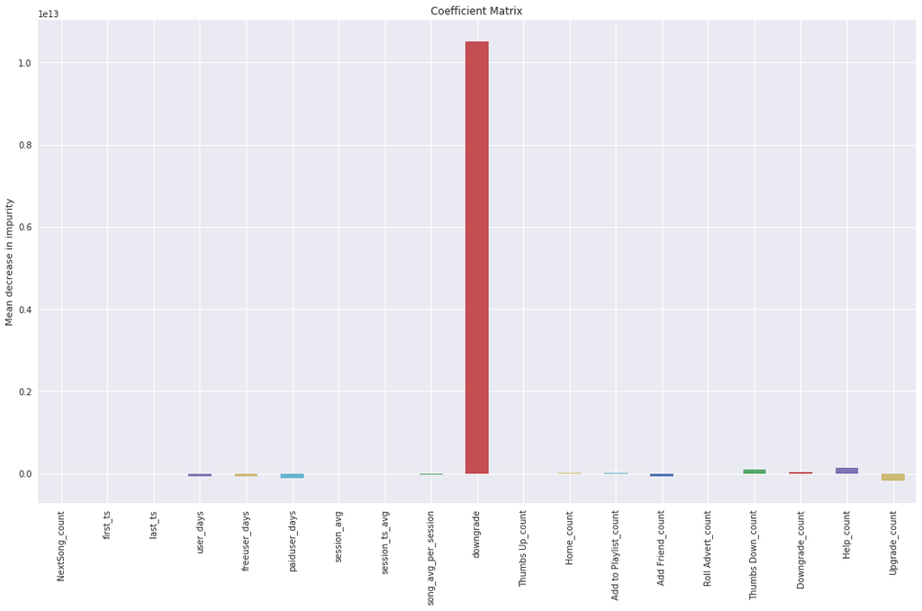

```python
lr_model_cm = lr_model.stages[8].coefficientMatrix

lr_importances = pd.Series(lr_model_cm.values, index=input_cols)
fig, ax = plt.subplots()
lr_importances.plot.bar(ax=ax)
ax.set_title("Coefficient Matrix")
ax.set_ylabel("Mean decrease in impurity")
fig.tight_layout()
```

## Random Forest Model

```python
rf = RandomForestClassifier(labelCol="churn", featuresCol="normalized_features")

#pipeline
rf_pipeline = Pipeline(stages=[
    gender_idxr,
    lavel_idxr,
    location_idxr,
    useragent_idxr,
    location_ohe,
    useragent_ohe,
    assembler,
    normalizer,
    rf
])

#train
rf_model = rf_pipeline.fit(train)
```

```python
# predict
rf_pred = rf_model.transform(test)
```

```python
#evaluate
evaluate(rf_pred)
```

```
f1 score: 0.796840318579449, accuracy: 0.8260869565217391
```

```python
# validation
rf_valid = rf_model.transform(valid)
evaluate(rf_valid)
```

```
f1 score: 0.728448275862069, accuracy: 0.8125
```

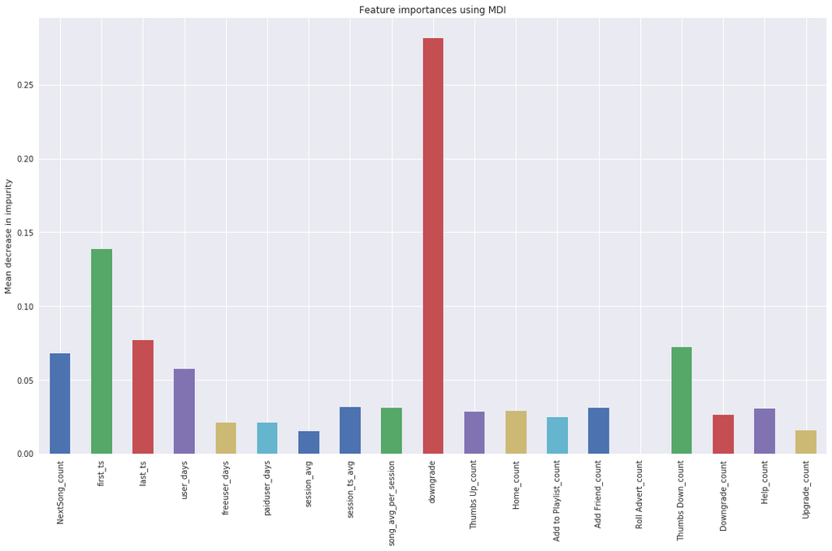

```python
#plot matrix
rf_model_fi = rf_model.stages[8].featureImportances

forest_importances = pd.Series(rf_model_fi, index=input_cols)

fig, ax = plt.subplots()
forest_importances.plot.bar(ax=ax)
ax.set_title("Feature importances using MDI")
ax.set_ylabel("Mean decrease in impurity")
fig.tight_layout()
```

## Gradient-Boosted Trees (GBTs)

```python
gbt = GBTClassifier(labelCol="churn", featuresCol="normalized_features")

# build pipeline
gbt_pipeline = Pipeline(stages=[
    gender_idxr,
    lavel_idxr,
    location_idxr,
    useragent_idxr,
    location_ohe,
    useragent_ohe,
    assembler,
    normalizer,
    gbt
])


# train
gbt_model = gbt_pipeline.fit(train)
```

```python
# predict
gbt_pred = gbt_model.transform(test)
```

```python
#evaluate
evaluate(gbt_pred)
```

```
f1 score: 0.7578715120051914, accuracy: 0.7608695652173914
```

```python
# validation
gbt_valid = gbt_model.transform(valid)
evaluate(gbt_valid)
```

```
f1 score: 0.7972222222222223, accuracy: 0.8125
```

[output not shown]

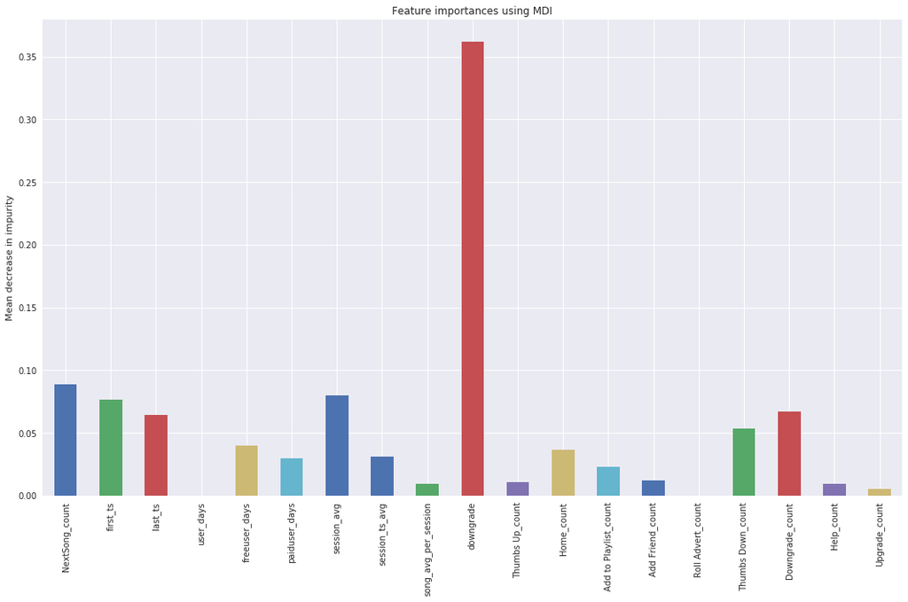

```python
#plot matrix
gbt_model_fi = gbt_model.stages[8].featureImportances

gbt_importances = pd.Series(gbt_model_fi, index=input_cols)
fig, ax = plt.subplots()
gbt_importances.plot.bar(ax=ax)
ax.set_title("Feature importances using MDI")
ax.set_ylabel("Mean decrease in impurity")
fig.tight_layout()
```

## Tuning

```python
paramGrid = ParamGridBuilder() \
    .addGrid(rf.numTrees, [50, 100]) \
    .addGrid(rf.maxDepth, [10, 20]) \
    .build()

crossval = CrossValidator(estimator=rf_pipeline,
                  estimatorParamMaps=paramGrid,
                  evaluator=MulticlassClassificationEvaluator(labelCol="churn", predictionCol="prediction", metricName="f1"),
                  numFolds=2)

cv_model = crossval.fit(train)
```

```python
#predict
cv_preds = cv_model.transform(test)
```

```python
#evaluate
evaluate(cv_preds)
```

```
f1 score: 0.7879450616743942, accuracy: 0.8043478260869565
```

```python
#best model
best_pipeline = cv_model.bestModel
best_model = best_pipeline.stages[8]
best_model.extractParamMap()
```

```
{Param(parent='RandomForestClassifier_2ccc44e88012', name='cacheNodeIds', doc='If false, the algorithm will pass trees to executors to match instances with nodes. If true, the algorithm will cache node IDs for each instance. Caching can speed up training of deeper trees.'): False,
 Param(parent='RandomForestClassifier_2ccc44e88012', name='checkpointInterval', doc='set checkpoint interval (>= 1) or disable checkpoint (-1). E.g. 10 means that the cache will get checkpointed every 10 iterations. Note: this setting will be ignored if the checkpoint directory is not set in the Spa…
 Param(parent='RandomForestClassifier_2ccc44e88012', name='featureSubsetStrategy', doc='The number of features to consider for splits at each tree node. Supported options: auto, all, onethird, sqrt, log2, (0.0-1.0], [1-n].'): 'auto',
 Param(parent='RandomForestClassifier_2ccc44e88012', name='featuresCol', doc='features column name'): 'normalized_features',
 Param(parent='RandomForestClassifier_2ccc44e88012', name='impurity', doc='Criterion used for information gain calculation (case-insensitive). Supported options: entropy, gini'): 'gini',
 Param(parent='RandomForestClassifier_2ccc44e88012', name='labelCol', doc='label column name'): 'churn',
 Param(parent='RandomForestClassifier_2ccc44e88012', name='maxBins', doc='Max number of bins for discretizing continuous features.  Must be >=2 and >= number of categories for any categorical feature.'): 32,
 Param(parent='RandomForestClassifier_2ccc44e88012', name='maxDepth', doc='Maximum depth of the tree. (>= 0) E.g., depth 0 means 1 leaf node; depth 1 means 1 internal node + 2 leaf nodes.'): 10,
 Param(parent='RandomForestClassifier_2ccc44e88012', name='maxMemoryInMB', doc='Maximum memory in MB allocated to histogram aggregation.'): 256,
 Param(parent='RandomForestClassifier_2ccc44e88012', name='minInfoGain', doc='Minimum information gain for a split to be considered at a tree node.'): 0.0,
 Param(parent='RandomForestClassifier_2ccc44e88012', name='minInstancesPerNode', doc='Minimum number of instances each child must have after split.  If a split causes the left or right child to have fewer than minInstancesPerNode, the split will be discarded as invalid. Should be >= 1.'): 1,
 Param(parent='RandomForestClassifier_2ccc44e88012', name='numTrees', doc='Number of trees to train (>= 1)'): 50,
 Param(parent='RandomForestClassifier_2ccc44e88012', name='predictionCol', doc='prediction column name'): 'prediction',
 Param(parent='RandomForestClassifier_2ccc44e88012', name='probabilityCol', doc='Column name for predicted class conditional probabilities. Note: Not all models output well-calibrated probability estimates! These probabilities should be treated as confidences, not precise probabilities'): 'probabili…
 Param(parent='RandomForestClassifier_2ccc44e88012', name='rawPredictionCol', doc='raw prediction (a.k.a. confidence) column name'): 'rawPrediction',
 Param(parent='RandomForestClassifier_2ccc44e88012', name='seed', doc='random seed'): -9070437798122316477,
 Param(parent='RandomForestClassifier_2ccc44e88012', name='subsamplingRate', doc='Fraction of the training data used for learning each decision tree, in range (0, 1].'): 1.0}
```

# Final Steps

Clean up your code, adding comments and renaming variables to make the code easier to read and maintain. Refer to the Spark Project Overview page and Data Scientist Capstone Project Rubric to make sure you are including all components of the capstone project and meet all expectations. Remember, this includes thorough documentation in a README file in a Github repository, as well as a web app or blog post.